# Accenture_2_Sijin

## Questions for the Data Challenge

```python
import pandas as pd

# Read data from CSV files
Customer_Profile = pd.read_csv('https://storage.googleapis.com/datalynn-datasets/interview-challenge/finance/Accenture_2/Customer_Profile.csv')
Billing_Data = pd.read_csv('https://storage.googleapis.com/datalynn-datasets/interview-challenge/finance/Accenture_2/Billing_Data.csv')
Customer_Service_Records = pd.read_csv('https://storage.googleapis.com/datalynn-datasets/interview-challenge/finance/Accenture_2/Customer_Service_Records.csv')
Market_Trends = pd.read_csv('https://storage.googleapis.com/datalynn-datasets/interview-challenge/finance/Accenture_2/Market_Trends.csv')
```

```python
import sqlite3
import pandas as pd
from dateutil.parser import parse

# Load datasets into SQLite database
conn = sqlite3.connect('telecom_data.db')
Customer_Profile.to_sql('Customer_Profile', conn, if_exists='replace', index=False)
Billing_Data.to_sql('Billing_Data', conn, if_exists='replace', index=False)
Customer_Service_Records.to_sql('Customer_Service_Records', conn, if_exists='replace', index=False)
Market_Trends.to_sql('Market_Trends', conn, if_exists='replace', index=False)
```

```
1000
```

### **1. "Identification of Churn Indicators (SQL)"**

**Question:**

Utilizing the 'Customer_Profile', 'Billing_Data', and 'Customer_Service_Records' tables, extract key indicators that could potentially signal customer churn. This might involve metrics like the frequency of service complaints, payment patterns, and changes in usage. How would you utilize SQL to process and analyze these data sets and define churn indicators? Describe the peculiarities you might expect in each churn signal group.

**Answer:**

```python
query = """
SELECT
    c.Churn,
    AVG(cs.Total_Complaints) AS Avg_Total_Complaints,
    AVG(cs.Unresolved_Complaints) AS Avg_Unresolved_Complaints,
    AVG(b.Late_Payments) AS Avg_Late_Payments,
    AVG(c.Tenure) AS Avg_Tenure
FROM
    Customer_Profile c
JOIN
    Billing_Data b ON c.Customer_ID = b.Customer_ID
JOIN
    Customer_Service_Records cs ON c.Customer_ID = cs.Customer_ID
GROUP BY
    c.Churn;
"""

result = pd.read_sql_query(query, conn)
result
```

|  | Churn | Avg_Total_Complaints | Avg_Unresolved_Complaints | Avg_Late_Payments | Avg_Tenure |
| --- | --- | --- | --- | --- | --- |
| 0 | No | 4.948363 | 2.540302 | 1.965995 | 34.984887 |
| 1 | Yes | 7.781553 | 3.966019 | 3.975728 | 37.577670 |

### **2. "Analysis of Churn Indicators Across Different Customer Segments (Python)"**

**Question:**

Dive deeper into the customer segments that have high churn rates. Using Python, identify patterns in the churn indicators across different customer demographics like age, location, or subscription type. Discuss your approach in handling cases where some segments have sparse data. Explain how your findings could refine the understanding of customer churn across different segments.

**Answer:**

```python
# Merging Dataframes
df = pd.merge(Customer_Profile, Billing_Data, on='Customer_ID')
df = pd.merge(df, Customer_Service_Records, on='Customer_ID')

# Group by location, age and subscription type
churn_by_segments = df.groupby(['Location', 'Age', 'Subscription_Type', 'Churn']).agg({'Customer_ID':'count'}).reset_index()
print(churn_by_segments)
```

```
    Location  Age Subscription_Type Churn  Customer_ID
0    Alabama   21            Plan_B    No            1
1    Alabama   26            Plan_A    No            2
2    Alabama   33            Plan_B    No            1
3    Alabama   37            Plan_A    No            1
4    Alabama   37            Plan_B    No            1
..       ...  ...               ...   ...          ...
931  Wyoming   50            Plan_A    No            1
932  Wyoming   57            Plan_B    No            2
933  Wyoming   60            Plan_B    No            1
934  Wyoming   61            Plan_A    No            1
935  Wyoming   66            Plan_B    No            1

[936 rows x 5 columns]
```

### **3. "Investigation of the Impact of Complaint Resolution on Churn in High-Tenure Customers (Python)"**

**Question:**

High-tenure customers are generally more valuable for a company. Preserving their loyalty and reducing their churn rate is critical. Assume that you've noticed a higher churn rate amongst high-tenure customers who have unresolved complaints. Using Python, perform an analysis to confirm if unresolved complaints significantly influence the churn rate in high-tenure customers compared to those with resolved complaints.

Moreover, propose an actionable strategy for reducing churn in this specific customer segment based on your findings. Discuss how your findings might shape the company's customer service approach for high-tenure customers and detail how it could potentially improve customer satisfaction and reduce churn in this segment.

**Answer:**

```python
# Merge Customer_Profile and Customer_Service_Records on 'Customer_ID'
merged_data = pd.merge(Customer_Profile, Customer_Service_Records, on='Customer_ID')

# Filter for high-tenure customers
avg_tenure = merged_data['Tenure'].mean()
high_tenure_customers = merged_data[merged_data['Tenure'] > avg_tenure]

# Calculate churn rate for high-tenure customers with unresolved complaints
high_tenure_unresolved_complaints = high_tenure_customers[high_tenure_customers['Unresolved_Complaints'] > 0]
churn_rate_unresolved_complaints = high_tenure_unresolved_complaints['Churn'].value_counts(normalize=True)['Yes']

# Calculate churn rate for high-tenure customers with no unresolved complaints
high_tenure_resolved_complaints = high_tenure_customers[high_tenure_customers['Unresolved_Complaints'] == 0]
churn_rate_resolved_complaints = high_tenure_resolved_complaints['Churn'].value_counts(normalize=True)['Yes']

print(f"Churn rate for high-tenure customers with unresolved complaints: {churn_rate_unresolved_complaints}")
print(f"Churn rate for high-tenure customers with no unresolved complaints: {churn_rate_resolved_complaints}")
```

```
Churn rate for high-tenure customers with unresolved complaints: 0.2336448598130841
Churn rate for high-tenure customers with no unresolved complaints: 0.19753086419753085
```

### **4. "Creating Customer Interaction Graphs (Python)"**

**Question:**

Customers often interact with the telecommunication service in multiple ways - through calling customer service, online chat, billing, service usage, etc. Using Python, construct a graph data structure to map these interactions for a set of customers, specifically focusing on the total number of service calls made by customers. Explore and describe any emergent patterns in this graph that could signal churn. Discuss the implications of densely connected subgraphs, isolated nodes, and loosely connected nodes with respect to their service call behavior.

**Answer:**

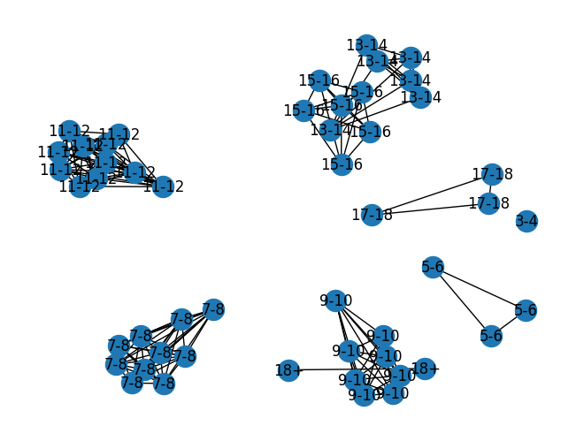

```python
import matplotlib.pyplot as plt
import networkx as nx
import numpy as np

# Create a copy of the 'Customer_Service_Records' dataframe with a subset of customers
subset_data = Customer_Service_Records.head(50).copy()

# Categorize 'Total_Calls' into ranges
# subset_data['Total_Calls_Range'] = pd.cut(subset_data['Total_Calls'], bins=[0, 5, 10, 20, np.inf], labels=['0-5', '6-10', '11-20', '20+'])
subset_data['Total_Calls_Range'] = pd.cut(subset_data['Total_Calls'], bins=[0, 2, 4, 6, 8, 10, 12, 14, 16, 18, np.inf], labels=['0-2', '3-4', '5-6', '7-8', '9-10', '11-12', '13-14', '15-16', '17-18', '18+'])

# Create an empty graph
G = nx.Graph()

# Add nodes to the graph from the 'Customer_ID' column
G.add_nodes_from(subset_data['Customer_ID'])

# Create a dictionary of labels for the nodes
labels = {row['Customer_ID']:row['Total_Calls_Range'] for index, row in subset_data.iterrows()}

# Iterate over the dataframe and add edges between customers who have the same 'Total_Calls_Range'
for i in range(len(subset_data)):
    for j in range(i+1, len(subset_data)):
        if subset_data.iloc[i]['Total_Calls_Range'] == subset_data.iloc[j]['Total_Calls_Range']:
            G.add_edge(subset_data.iloc[i]['Customer_ID'], subset_data.iloc[j]['Customer_ID'])

# Create a layout for the nodes
pos = nx.spring_layout(G, k=0.6)

# Draw the graph using the layout
nx.draw(G, pos, with_labels=False)  # Disable the default labels

# Draw the labels on the graph
nx.draw_networkx_labels(G, pos, labels=labels)

plt.show()
```

### **5. "Feature Engineering for Churn Prediction (Python)"**

**Question:**

Develop new features such as 'Average_Service_Complaints', 'Payment_Frequency_Change', and 'Usage_Decrease' ratios from the identified churn indicators. Using Python, examine how these engineered features contribute to predicting customer churn. Elaborate on how these newly created features could potentially enhance the predictive power of the churn model.

**Answer:**

```python
# Add 'Average_Service_Complaints'
Customer_Service_Records['Average_Service_Complaints'] = Customer_Service_Records['Total_Complaints'] / Customer_Profile['Tenure']

# Merge 'Late_Payments' into 'Customer_Service_Records'
Customer_Service_Records = pd.merge(Customer_Service_Records, Billing_Data[['Customer_ID', 'Late_Payments']], on='Customer_ID')

# Add 'Payment_Frequency_Change' based on 'Late_Payments'
Customer_Service_Records['Payment_Frequency_Change'] = Customer_Service_Records['Late_Payments'].apply(lambda x: 'Yes' if x > 0 else 'No')

# Merge 'Monthly_Charge' and 'Total_Charges' into 'Customer_Service_Records'
Customer_Service_Records = pd.merge(Customer_Service_Records, Billing_Data[['Customer_ID', 'Monthly_Charge', 'Total_Charges']], on='Customer_ID')

# Add 'Usage_Decrease'
Customer_Service_Records['Usage_Decrease'] = np.where(Customer_Service_Records['Total_Charges'] < (Customer_Service_Records['Monthly_Charge'] * Customer_Profile['Tenure']), 'Yes', 'No')
```

```python
Customer_Service_Records
```

|  | Customer_ID | Total_Calls | Total_Complaints | Resolved_Complaints | Unresolved_Complaints | Average_Service_Complaints | Late_Payments | Payment_Frequency_Change | Monthly_Charge | Total_Charges | Usage_Decrease |
| --- | --- | --- | --- | --- | --- | --- | --- | --- | --- | --- | --- |
| 0 | 1 | 8 | 6 | 4 | 2 | 0.200000 | 2 | Yes | 57.38 | 1721.40 | No |
| 1 | 2 | 10 | 4 | 2 | 2 | 0.285714 | 1 | Yes | 69.06 | 966.84 | No |
| 2 | 3 | 16 | 7 | 4 | 3 | 0.350000 | 3 | Yes | 25.36 | 507.20 | No |
| 3 | 4 | 16 | 6 | 0 | 6 | 0.142857 | 4 | Yes | 44.73 | 1878.66 | No |
| 4 | 5 | 16 | 10 | 2 | 8 | 0.222222 | 3 | Yes | 80.12 | 3605.40 | No |
| ... | ... | ... | ... | ... | ... | ... | ... | ... | ... | ... | ... |
| 995 | 996 | 13 | 3 | 0 | 3 | 0.083333 | 2 | Yes | 20.75 | 747.00 | No |
| 996 | 997 | 13 | 2 | 1 | 1 | 0.071429 | 1 | Yes | 99.12 | 2775.36 | No |
| 997 | 998 | 9 | 6 | 6 | 0 | 1.500000 | 0 | No | 78.37 | 313.48 | No |
| 998 | 999 | 17 | 11 | 2 | 9 | 1.375000 | 4 | Yes | 32.37 | 258.96 | No |
| 999 | 1000 | 4 | 7 | 1 | 6 | 1.400000 | 1 | Yes | 97.73 | 488.65 | Yes |

1000 rows × 11 columns

### **6. "Development and Optimization of Churn Prediction Model (Python)"**

**Question:**

Given the insights and features derived from the previous questions, identify which could be most predictive of customer churn. Noting the presence of imbalanced data, discuss your approach to handle this situation for robust churn prediction. Specifically, try both oversampling and undersampling techniques, and compare their performance. Implement a predictive model in Python using these features and elaborate on how this model will steer proactive customer retention strategies. Validate your model to prevent overfitting and demonstrate how the model's outcomes could be integrated into business strategies to decrease overall churn rates and heighten profitability. Discuss how your handling of imbalanced data affects your model's performance and your interpretation of the results.

**Answer:**

```
Tuned Random Forest Parameters with undersampling: {'max_depth': None, 'min_samples_leaf': 1, 'min_samples_split': 5, 'n_estimators': 200}
Best score with undersampling is 0.8484848484848484
              precision    recall  f1-score   support

           0       0.95      0.91      0.93       159
           1       0.71      0.83      0.76        41

    accuracy                           0.90       200
   macro avg       0.83      0.87      0.85       200
weighted avg       0.90      0.90      0.90       200
```

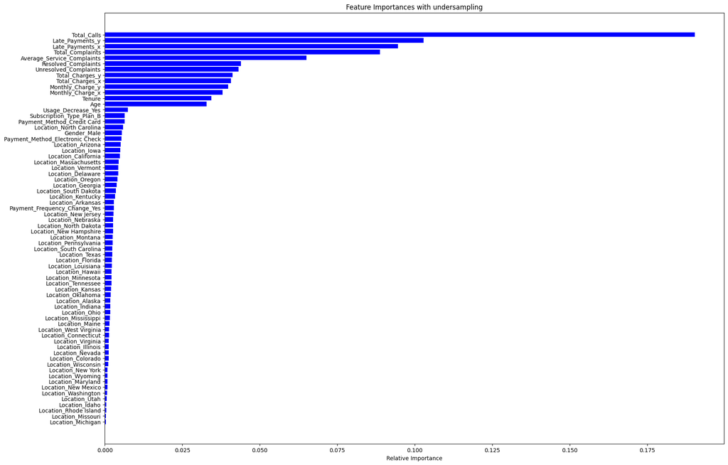

```
Tuned Random Forest Parameters with oversampling: {'max_depth': None, 'min_samples_leaf': 1, 'min_samples_split': 2, 'n_estimators': 200}
Best score with oversampling is 0.9291338582677164
              precision    recall  f1-score   support

           0       0.96      0.96      0.96       159
           1       0.85      0.83      0.84        41

    accuracy                           0.94       200
   macro avg       0.90      0.90      0.90       200
weighted avg       0.93      0.94      0.93       200
```

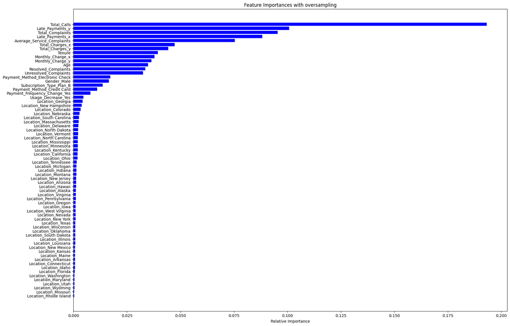

```python
from sklearn.ensemble import RandomForestClassifier
from sklearn.metrics import classification_report, confusion_matrix
from sklearn.model_selection import GridSearchCV
from sklearn.model_selection import train_test_split
from imblearn.under_sampling import RandomUnderSampler
from imblearn.over_sampling import SMOTE
import matplotlib.pyplot as plt
import numpy as np
import pandas as pd

# Merging all datasets together on 'Customer_ID'
data = pd.merge(Customer_Profile, Billing_Data, on='Customer_ID')
data = pd.merge(data, Customer_Service_Records, on='Customer_ID')

# Convert 'Churn' into a binary variable
data['Churn'] = data['Churn'].map({'Yes': 1, 'No': 0})

# Converting other categorical variables into dummy variables
data = pd.get_dummies(data, columns=['Gender', 'Location', 'Subscription_Type', 'Payment_Method', 'Payment_Frequency_Change', 'Usage_Decrease'], drop_first=True)

# Split the data into features and target variable
X = data.drop(['Customer_ID', 'Churn'], axis=1)
y = data['Churn']

# Splitting the data into training and test sets
X_train, X_test, y_train, y_test = train_test_split(X, y, test_size=0.2, random_state=42)

# Apply RandomUnderSampler
rus = RandomUnderSampler(random_state=2)
X_train_rus, y_train_rus = rus.fit_resample(X_train, y_train)

# Apply SMOTE
sm = SMOTE(random_state=2)
X_train_ros, y_train_ros = sm.fit_resample(X_train, y_train)

# Set up hyperparameter grid for tuning
param_grid = {
    'n_estimators': [100, 200, 300],
    'max_depth': [None, 5, 10],
    'min_samples_split': [2, 5, 10],
    'min_samples_leaf': [1, 3, 5]
}

# Instantiate a RandomForestClassifier
rf = RandomForestClassifier(class_weight={0: 0.8, 1: 0.2})

# Instantiate the GridSearchCV object
rf_cv = GridSearchCV(rf, param_grid, cv=5)

# Fit it to the undersampled data
rf_cv.fit(X_train_rus, y_train_rus)

# Print the tuned parameters and score for undersampled data
print("Tuned Random Forest Parameters with undersampling: {}".format(rf_cv.best_params_))
print("Best score with undersampling is {}".format(rf_cv.best_score_))

# Predict the labels of the test set for undersampled data
y_pred_rus = rf_cv.predict(X_test)

# Generate the classification report for undersampled data
print(classification_report(y_test, y_pred_rus, zero_division=1))

# Show feature importances for undersampled data
importances_rus = rf_cv.best_estimator_.feature_importances_
features = X.columns
indices_rus = np.argsort(importances_rus)

plt.figure(figsize=(20,14))
plt.title('Feature Importances with undersampling')
plt.barh(range(len(indices_rus)), importances_rus[indices_rus], color='b', align='center')
plt.yticks(range(len(indices_rus)), [features[i] for i in indices_rus])
plt.xlabel('Relative Importance')
plt.show()

# Fit it to the oversampled data
rf_cv.fit(X_train_ros, y_train_ros)

# Print the tuned parameters
print("Tuned Random Forest Parameters with oversampling: {}".format(rf_cv.best_params_))
print("Best score with oversampling is {}".format(rf_cv.best_score_))

# Predict the labels of the test set for oversampled data
y_pred_ros = rf_cv.predict(X_test)

# Generate the classification report for oversampled data
print(classification_report(y_test, y_pred_ros, zero_division=1))

# Show feature importances for oversampled data
importances_ros = rf_cv.best_estimator_.feature_importances_
indices_ros = np.argsort(importances_ros)

plt.figure(figsize=(20,14))
plt.title('Feature Importances with oversampling')
plt.barh(range(len(indices_ros)), importances_ros[indices_ros], color='b', align='center')
plt.yticks(range(len(indices_ros)), [features[i] for i in indices_ros])
plt.xlabel('Relative Importance')
plt.show()
```